# Isye603 HW4

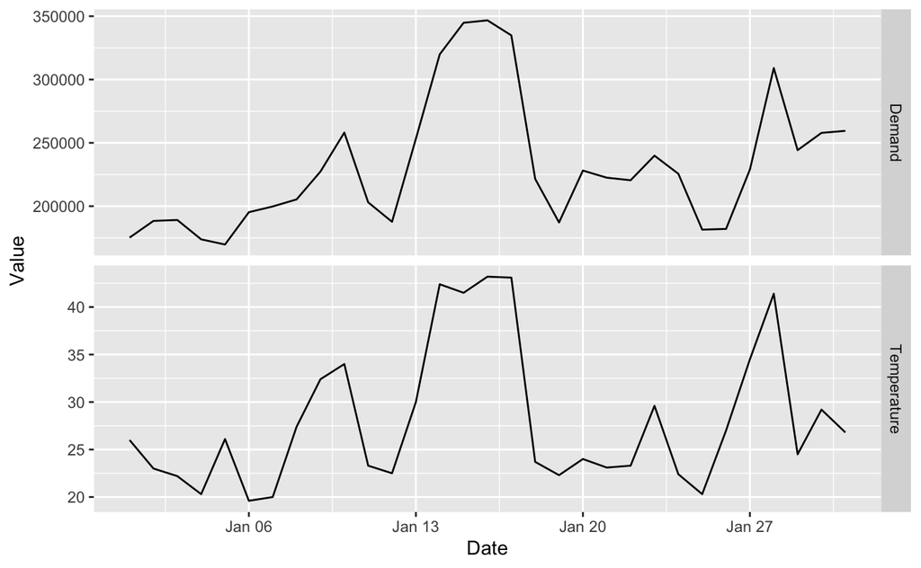

```r
#Problem 1a - Plot Data and Find Regression Model Demand with temperarture as a predictor Variable
#Demand is the response variable - what we wish to estimate / predict
#Temp - is the predictor variable - What we used to predict.
library(fpp3)
library(ggplot2)
library(forecast)
jan14_vic_elec <- vic_elec %>%
  filter(yearmonth(Time) == yearmonth("2014 Jan")) %>%
  index_by(Date = as_date(Time)) %>%
  summarise(                ##Aggregating the data based on total demand and max temperature
    Demand = sum(Demand),
    Temperature = max(Temperature)
  )

jan14_vic_elec %>%
  gather("Variable", "Value", Demand, Temperature) %>%
  ggplot(aes(x = Date, y = Value)) +
  geom_line() +
  facet_grid(vars(Variable), scales = "free_y")
```

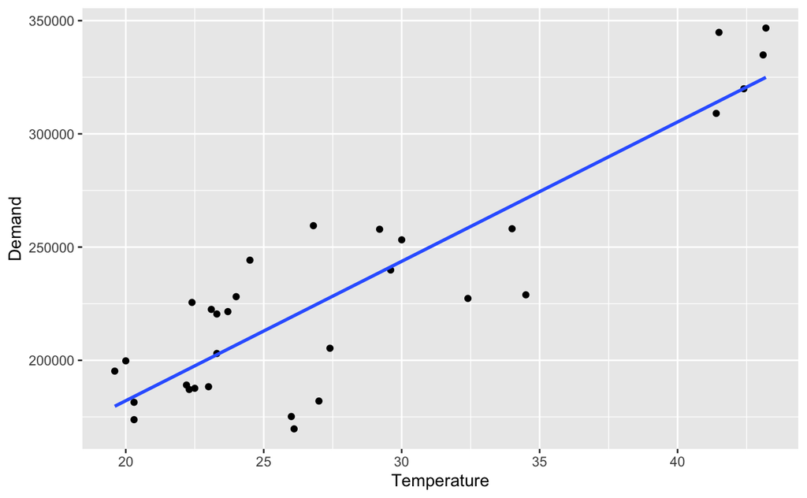

```r
jan14_vic_elec %>%
  ggplot(aes(x=Temperature, y=Demand)) +
  geom_point() +
  geom_smooth(method="lm", se=FALSE)
```

```r
#Estimating the regression
fit <- jan14_vic_elec %>% model(TSLM(Demand ~ Temperature)) %>%
  report()
```

```
Series: Demand
Model: TSLM

Residuals:
     Min       1Q   Median       3Q      Max
-49978.2 -10218.9   -121.3  18533.2  35440.6

Coefficients:
            Estimate Std. Error t value Pr(>|t|)
(Intercept)  59083.9    17424.8   3.391  0.00203 **
Temperature   6154.3      601.3  10.235 3.89e-11 ***
---
Signif. codes:  0 ‘***’ 0.001 ‘**’ 0.01 ‘*’ 0.05 ‘.’ 0.1 ‘ ’ 1

Residual standard error: 24540 on 29 degrees of freedom
Multiple R-squared: 0.7832, Adjusted R-squared: 0.7757
F-statistic: 104.7 on 1 and 29 DF, p-value: 3.8897e-11
```

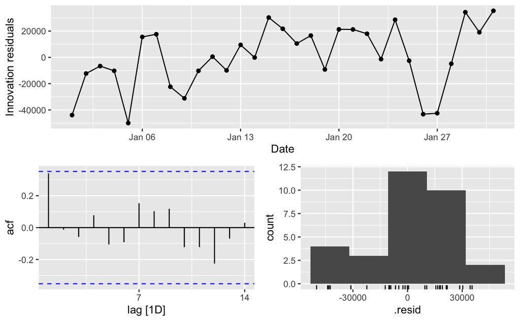

```r
#Problem 1b- Plotting the residuals
fit %>% gg_tsresiduals()
```

```r
#Problem 1c- forecasting electricity demand with a temp of 15 and comparing it to the forecast if
# temp = 35

#Forecast of Electricity Demand at Temp = 15
forecast_15 <-fit %>%
  forecast(
    new_data(jan14_vic_elec, 1) %>%
      mutate(Temperature = 15)
  ) #%>%
forecast_15 # Printing the forecast
```

| .model | Date | Demand | .mean | Temperature |
| --- | --- | --- | --- | --- |
| TSLM(Demand ~ Temperature) | 2014-02-01 |  | 151398.4 | 15 |

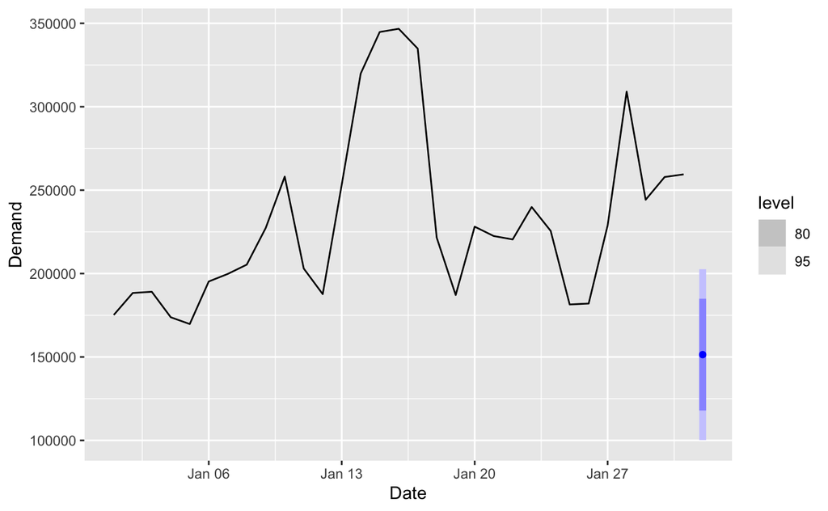

```r
forecast_15 %>% autoplot(jan14_vic_elec) # creating an autoplot at temp = 15
```

```r
#Forecast of Electricity Demand at Temp = 15
forecast_35 <-fit %>%
  forecast(
    new_data(jan14_vic_elec, 1) %>%
      mutate(Temperature = 35)
  )
forecast_35 #Printing the forecast
```

| .model | Date | Demand | .mean | Temperature |
| --- | --- | --- | --- | --- |
| TSLM(Demand ~ Temperature) | 2014-02-01 |  | 274484.2 | 35 |

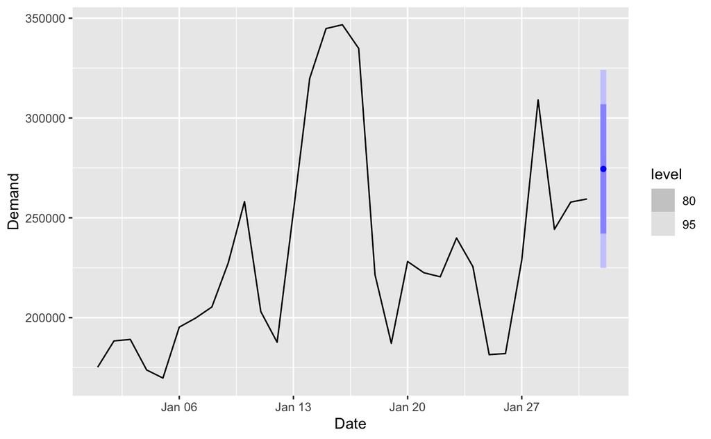

```r
forecast_35 %>% autoplot(jan14_vic_elec)  # creating an autoplot at temp = 15
```

```r
#fit %>% forecast(new_data(jan14_vic_elec, 1) %>% mutate(Temperature = 15)) %>%
 # mutate(interval = hilo(.distribution, 80))

#Problem 1d - Give prediction intervals for your forecast
forecast_15_hilo <- forecast_15%>% hilo() #Extracting hi and lo value for the forecast 15 interval

# Output model interval values for 95% interval for forecast at temp 15
forecast_15_hilo$`95%`[1]
```

```
<hilo[1]>
[1] [100179.4, 202617.3]95
```

```r
# Output model interval values for 80% interval for forecast at temp 15
forecast_15_hilo$`80%`[1]
```

```
<hilo[1]>
[1] [117908.1, 184888.6]80
```

```r
forecast_35_hilo <- forecast_35%>% hilo() #Extracting hi and lo value for the forecast 35 interval

# Output model interval values for 95% interval for forecast at temp 35
forecast_35_hilo$`95%`[1]
```

```
<hilo[1]>
[1] [224939.1, 324029.4]95
```

```r
# Output model interval values for 80% interval for forecast at temp 35
forecast_35_hilo$`80%`[1]
```

```
<hilo[1]>
[1] [242088.4, 306880.1]80
```

## Problem 1a

There is a positive slope because there exists a relation between temperature and the demand for electricity. The demand for electricity depends on the weather .So, warmer days might have higher electricity demeand due to the use of air conditioners.

## Problem 1b

The model is adrequate. Howerver, there are a few outliers.

## Problem 1c

```r
#Problem 2
#Problem 2a - Plotting a time series plot for pre sept 11
#The sept11 ts data (time series) has to first be split into pre and post sept 11
library(dplyr)
library(tidyverse)
library(readxl) #reading an xls file in
Sept11.data <- read_excel("Sept11Travel.xls") #read my file in as xls
str(Sept11.data ) #Checking Structure of my data
```

```
tibble [172 × 4] (S3: tbl_df/tbl/data.frame)
 $ Month         : POSIXct[1:172], format: "1990-01-01" "1990-02-01" "1990-03-01" ...
 $ Air RPM (000s): num [1:172] 35153577 32965187 39993913 37981886 38419672 ...
 $ Rail PM       : num [1:172] 4.54e+08 4.35e+08 5.68e+08 5.68e+08 5.40e+08 ...
 $ VMT (billions): num [1:172] 163 153 178 179 189 ...
```

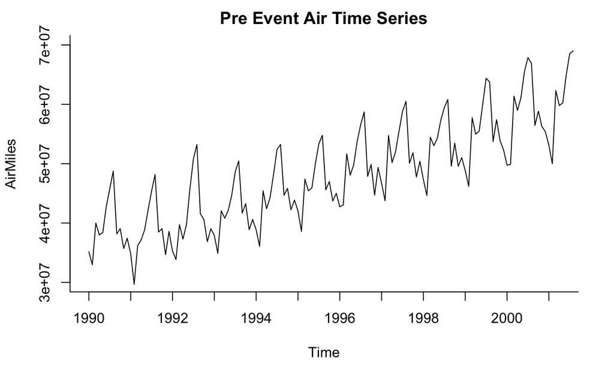

```r
#Created a time series data before 911 which is between Jan 1990 to Aug 2001
AirMiles.ts<-ts(Sept11.data$`Air RPM (000s)`, start = c(1990,1), end = c(2001, 8), frequency = 12)
plot.ts(AirMiles.ts, ylim = c(30000000, 70000000),  ylab = "AirMiles", xlab = "Time", bty = "l", xaxt = "n", xlim = c(1990,2001.25), main = "Pre Event Air Time Series")
axis(1, at = seq(1990, 2001, 1), labels = format(seq(1990, 2001, 1)))
```

```r
#Problem 2c
library(forecast)
nValid <- 36
nTrain <- length(AirMiles.ts) - nValid
Airtrain.ts <- window(AirMiles.ts, start = c(1990, 1), end = c(1990, nTrain))
Airvalid.ts <- window(AirMiles.ts, start = c(1990, nTrain + 1), end = c(1990, nTrain + nValid))

#Seasonally suppressed plot
quarterly <- aggregate(Airtrain.ts,nfrequency=4, FUN=sum)
plot(quarterly, bty="l")
#Problem 2c(i)
milesplot <- tslm(quarterly~trend)
summary(milesplot)
```

```
Call:
tslm(formula = quarterly ~ trend)

Residuals:
      Min        1Q    Median        3Q       Max
-15211683  -7961221  -1707186   7366425  20915379

Coefficients:
             Estimate Std. Error t value Pr(>|t|)
(Intercept) 108651224    3678954  29.533  < 2e-16 ***
trend         1456834     183376   7.945 4.56e-09 ***
---
Signif. codes:  0 ‘***’ 0.001 ‘**’ 0.01 ‘*’ 0.05 ‘.’ 0.1 ‘ ’ 1

Residual standard error: 10490000 on 32 degrees of freedom
Multiple R-squared:  0.6636,    Adjusted R-squared:  0.6531
F-statistic: 63.12 on 1 and 32 DF,  p-value: 4.562e-09
```

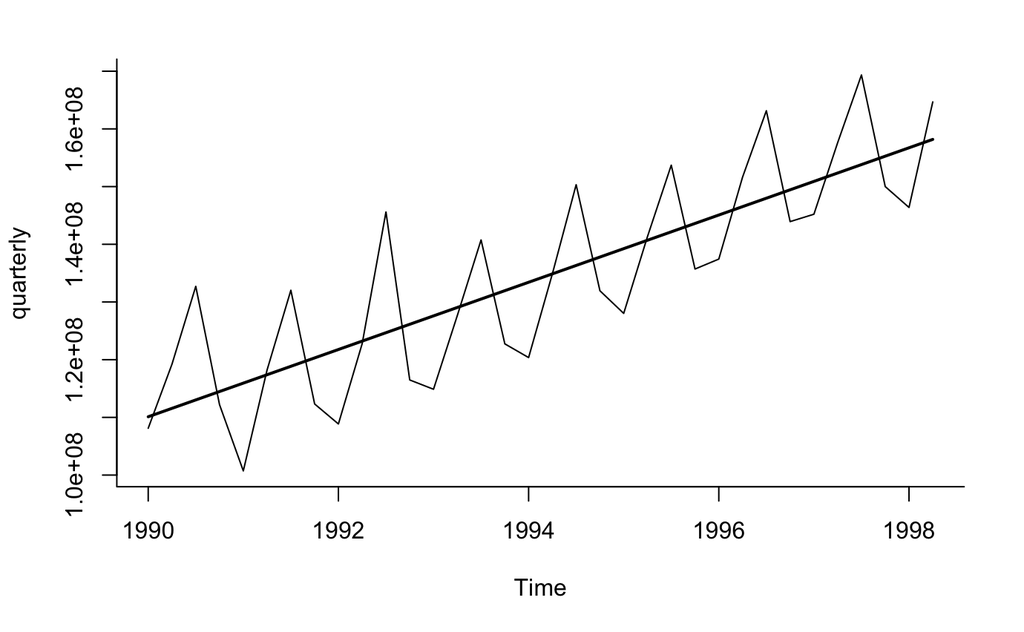

```r
lines(milesplot$fitted, lwd=2)
```

```r
#Problem 2d(i)
train.lm.trend.season <- tslm(Airtrain.ts~trend+I(trend^2)+season, lambda = 0)
summary(train.lm.trend.season)
```

```
Call:
tslm(formula = Airtrain.ts ~ trend + I(trend^2) + season, lambda = 0)

Residuals:
      Min        1Q    Median        3Q       Max
-0.100919 -0.014334 -0.001909  0.016961  0.076074

Coefficients:
              Estimate Std. Error  t value Pr(>|t|)
(Intercept)  1.734e+01  1.351e-02 1284.011  < 2e-16 ***
trend        2.471e-03  4.173e-04    5.922 5.72e-08 ***
I(trend^2)   1.082e-05  3.852e-06    2.810 0.006084 **
season2     -7.287e-02  1.482e-02   -4.917 3.93e-06 ***
season3      1.213e-01  1.482e-02    8.184 1.70e-12 ***
season4      7.154e-02  1.482e-02    4.827 5.64e-06 ***
season5      1.013e-01  1.482e-02    6.833 9.59e-10 ***
season6      1.816e-01  1.483e-02   12.246  < 2e-16 ***
season7      2.471e-01  1.483e-02   16.663  < 2e-16 ***
season8      2.809e-01  1.484e-02   18.934  < 2e-16 ***
season9      7.916e-02  1.530e-02    5.175 1.38e-06 ***
season10     9.847e-02  1.530e-02    6.436 5.83e-09 ***
season11     6.288e-05  1.530e-02    0.004 0.996731
season12     5.601e-02  1.531e-02    3.659 0.000426 ***
---
Signif. codes:  0 ‘***’ 0.001 ‘**’ 0.01 ‘*’ 0.05 ‘.’ 0.1 ‘ ’ 1

Residual standard error: 0.03143 on 90 degrees of freedom
Multiple R-squared:  0.9638,    Adjusted R-squared:  0.9586
F-statistic: 184.5 on 13 and 90 DF,  p-value: < 2.2e-16
```

```r
train.lm.trend.season.pred <- forecast(train.lm.trend.season, h = nValid, level = 0)
summary(train.lm.trend.season.pred)
```

```
Forecast method: Linear regression model

Model Information:

Call:
tslm(formula = Airtrain.ts ~ trend + I(trend^2) + season, lambda = 0)

Coefficients:
(Intercept)        trend   I(trend^2)      season2      season3      season4      season5
  1.734e+01    2.471e-03    1.082e-05   -7.287e-02    1.213e-01    7.154e-02    1.013e-01
    season6      season7      season8      season9     season10     season11     season12
  1.816e-01    2.471e-01    2.809e-01    7.916e-02    9.847e-02    6.288e-05    5.601e-02


Error measures:
                   ME    RMSE      MAE         MPE     MAPE      MASE      ACF1
Training set 11943.98 1324025 958690.3 -0.04296294 2.149753 0.4557994 0.6119907

Forecasts:
```

|  | Point Forecast | Lo 0 | Hi 0 |
| --- | --- | --- | --- |
| Sep 1998 | 53798539 | 53798539 | 53798539 |
| Oct 1998 | 55108819 | 55108819 | 55108819 |
| Nov 1998 | 50183094 | 50183094 | 50183094 |
| Dec 1998 | 53325719 | 53325719 | 53325719 |
| Jan 1999 | 50664886 | 50664886 | 50664886 |
| Feb 1999 | 47333081 | 47333081 | 47333081 |
| Mar 1999 | 57755427 | 57755427 | 57755427 |
| Apr 1999 | 55222168 | 55222168 | 55222168 |
| May 1999 | 57169213 | 57169213 | 57169213 |
| Jun 1999 | 62253992 | 62253992 | 62253992 |

[output cut: 26 more lines]

```r
#Problem 2d(ii)
train.lm.trend.season.residuals = log(Airtrain.ts)-log(train.lm.trend.season$fitted.values)
#summary(train.lm.trend.season$residuals)

#Problem 2e
#For air
AirMiles.ts.lm <- tslm(train.ts ~ trend, lambda = 0)
plot.ts(AirMiles.ts, ylim = c(30000000, 70000000),  ylab = "AirMiles", xlab = "Time", bty = "l", xaxt = "n", xlim = c(1990,2001.25), main = "Pre Event Air Time Series")
lines
```

```
function (x, ...)
UseMethod("lines")
<bytecode: 0x7f82e48d7be8>
<environment: namespace:graphics>
```

[figure not shown]

```r
lines(AirMiles.ts.lm$fitted, lwd = 2, col = "blue")
```

```r
# plot(train.lm.trend.season.pred, ylim = c(30000000, 70000000),  ylab = "AirMiles", xlab = "Time", bty = "l", xaxt = "n", xlim = c(1990,2001.25), main = "", flty = 2)
# axis(1, at = seq(1990, 2001, 1), labels = format(seq(1990, 2001, 1)))
#lines(train.lm.trend.season.pred$fitted, lwd = 2, col = "blue")
#plot(train.lm.trend.season)
```

## Problem 2a

The following time series components are present from the plot Level Trend Seasonality Random Noise

## Problem 2b

Linear regression model with dummy variable and trend will be adequate for forecasting this series because our data has both trend and seasonality.

## Problem 2d(i)

The statistical significance level for September and October coefficients are pretty close.

```r
#Problem 3b
library(forecast)
SouvenirSales.data <- read.csv(file ='SouvenirSales.csv', header = TRUE)
#creating the data in a time series format spanning from  Jan 1995 to  Dec. 2001 using a freq of 12
Sales.ts <- ts(SouvenirSales.data$Sales, start = c(1995,1), end = c(2001, 12), freq = 12)
fixed.nValid <- 12
# ssince we have a fixed valid the rest will be training.
fixed.nTrain <- length(Sales.ts) - fixed.nValid
#training period
train.ts <- window(Sales.ts, start = c(1995, 1), end = c(1995, fixed.nTrain))
#validation period
valid.ts <- window(Sales.ts, start = c(1995, fixed.nTrain + 1), end = c(1995, fixed.nTrain + fixed.nValid))

##Running the regression for modelA- used only training period only
Model_A <- tslm(train.ts ~ trend + season)
summary(Model_A)
```

```
Call:
tslm(formula = train.ts ~ trend + season)

Residuals:
   Min     1Q Median     3Q    Max
-12592  -2359   -411   1940  33651

Coefficients:
            Estimate Std. Error t value Pr(>|t|)
(Intercept) -3065.55    2640.26  -1.161  0.25029
trend         245.36      34.08   7.199 1.24e-09 ***
season2      1119.38    3422.06   0.327  0.74474
season3      4408.84    3422.56   1.288  0.20272
season4      1462.57    3423.41   0.427  0.67077
season5      1446.19    3424.60   0.422  0.67434
season6      1867.98    3426.13   0.545  0.58766
season7      2988.56    3427.99   0.872  0.38684
season8      3227.58    3430.19   0.941  0.35058
season9      3955.56    3432.73   1.152  0.25384
season10     4821.66    3435.61   1.403  0.16573
season11    11524.64    3438.82   3.351  0.00141 **
season12    32469.55    3442.36   9.432 2.19e-13 ***
---
Signif. codes:  0 ‘***’ 0.001 ‘**’ 0.01 ‘*’ 0.05 ‘.’ 0.1 ‘ ’ 1

Residual standard error: 5927 on 59 degrees of freedom
Multiple R-squared:  0.7903,    Adjusted R-squared:  0.7476
F-statistic: 18.53 on 12 and 59 DF,  p-value: 9.435e-16
```

```r
#Problem 3c
##Running the regression for modelB - using log as the output
Model_B <- tslm(log(train.ts) ~ trend + season)
summary(Model_B)
```

```
Call:
tslm(formula = log(train.ts) ~ trend + season)

Residuals:
    Min      1Q  Median      3Q     Max
-0.4529 -0.1163  0.0001  0.1005  0.3438

Coefficients:
            Estimate Std. Error t value Pr(>|t|)
(Intercept) 7.646363   0.084120  90.898  < 2e-16 ***
trend       0.021120   0.001086  19.449  < 2e-16 ***
season2     0.282015   0.109028   2.587 0.012178 *
season3     0.694998   0.109044   6.374 3.08e-08 ***
season4     0.373873   0.109071   3.428 0.001115 **
season5     0.421710   0.109109   3.865 0.000279 ***
season6     0.447046   0.109158   4.095 0.000130 ***
season7     0.583380   0.109217   5.341 1.55e-06 ***
season8     0.546897   0.109287   5.004 5.37e-06 ***
season9     0.635565   0.109368   5.811 2.65e-07 ***
season10    0.729490   0.109460   6.664 9.98e-09 ***
season11    1.200954   0.109562  10.961 7.38e-16 ***
season12    1.952202   0.109675  17.800  < 2e-16 ***
---
Signif. codes:  0 ‘***’ 0.001 ‘**’ 0.01 ‘*’ 0.05 ‘.’ 0.1 ‘ ’ 1

Residual standard error: 0.1888 on 59 degrees of freedom
Multiple R-squared:  0.9424,    Adjusted R-squared:  0.9306
F-statistic:  80.4 on 12 and 59 DF,  p-value: < 2.2e-16
```

```r
#Problem 3c(iii) - using model b to forecast the sale for February 2002
Feb2002_Forecast <-Model_B$coefficients["(Intercept)"] + Model_B$coefficients["trend"]*86 + Model_B$coefficients["season2"]

exp(Feb2002_Forecast)
```

```
(Intercept)
   17062.99
```

```r
#Problem 3d
#Model A forecast
Model_AForecast <- forecast(Model_A, h = fixed.nValid)
accuracy(Model_AForecast$mean, valid.ts)
```

```
               ME     RMSE      MAE      MPE     MAPE      ACF1 Theil's U
Test set 8251.513 17451.55 10055.28 10.53397 26.66568 0.3206228 0.9075924
```

```r
#Model B forecast
Model_BForecast <- forecast(Model_B, h = fixed.nValid)
accuracy(exp(Model_BForecast$mean), valid.ts)
```

```
               ME     RMSE      MAE      MPE    MAPE      ACF1 Theil's U
Test set 4824.494 7101.444 5191.669 12.35943 15.5191 0.4245018 0.4610253
```

## Problem 3b

i)From the coefficients December tends to have the highest average sales per year which might be due to the fact that is the holiday season.

2. The trend coefficient is (245.36). This shows that the average linear sales increase per month equals $245.36.

## Problem 3c

1. Exponential trend
2. The estimated trend coefficient of model b indicates that the sales increase by 2.112% on a monthly basis.
3. The forecasted sales for February 2002 is $17062

## Problem 3d

The RMSE for model B is smaller than that of model A. This makes it a better model for forecasting. Also, the MAPE of model B is 15.5 compared to the 26.7 for model A which is another reason why model B is the better model for foreacsting

## Problem 3e

I would model the influence of other variables on the sale to see how other external variables impact the sales. I would not separate the data into training and validation period because forecasting is not really necessary when studying the different components of sales.